# Harmonized Drug Dataset Version 1

James Bannon, Michael Tran

December 23, 2025

# 1 Overview

This report is a quality control walkthrough for the Harmonized Drug Dataset (HDD_v1) stored as a `MultiAssayExperiment` (MAE). The dataset harmonizes multiple drug-related assays and features across a shared compound universe (PubChem CID) so downstream analyses can operate on a consistent sample space.

## 1.1 Data Sources

The MAE is constructed in `workflow/scripts/construct_MAE.R`. It pulls processed experiments from `data/procdata/experiments/` and a `colData` table from `data/procdata/colData.csv`. Key sources (from `config/pipeline.yaml` and the workflow scripts) include:

- **BindingDB**: downloaded from the BindingDB site; filtered to human targets and cleaned, then transformed to a CID-by-target affinity matrix.
- **DeepChem datasets** (Tox21, ToxCast, SIDER, ClinTox): downloaded from DeepChem S3, then re-shaped to CID-by-assay matrices.
- **JUMP-CP** We accessed the compound info from the JUMP-CP dataset created by the Broad Institute.
- **LINCS** We accessed the compound info from the 2020 release of the LINCS L1000 perturbatione experiments. These experiments were also conducted by the Broad Institute.
- **Bioassays**: pulled from the BHKLab AnnotationDB alongside compound metadata, then filtered to gold-standard assays.
- **Fingerprints**: RDKit Morgan count fingerprints generated from SMILES.

# 2 Load HDD_v1

```r
library(MultiAssayExperiment)
library(SummarizedExperiment)
library(Matrix)
library(ggplot2)
library(dplyr)
library(tidyr)
library(glmnet)

hdd_v1 <- readRDS("data/results/HDD_v1.RDS")
hdd_v1
```

```
## A MultiAssayExperiment object of 12 listed
##  experiments with user-defined names and respective classes.
##  Containing an ExperimentList class object of length 12:
##  [1] SIDER: SummarizedExperiment with 27 rows and 324 columns
##  [2] BindingDB: SummarizedExperiment with 837 rows and 1183 columns
##  [3] Bioassays: SummarizedExperiment with 21 rows and 3488 columns
##  [4] Tox21: SummarizedExperiment with 12 rows and 31 columns
##  [5] ToxCast: SummarizedExperiment with 617 rows and 25 columns
##  [6] ClinTox: SummarizedExperiment with 2 rows and 118 columns
##  [7] fingerprint.Morgan.2.1024: SummarizedExperiment with 1024 rows and 3488 columns
##  [8] fingerprint.Morgan.2.2048: SummarizedExperiment with 2048 rows and 3488 columns
##  [9] fingerprint.Morgan.2.512: SummarizedExperiment with 512 rows and 329 columns
##  [10] fingerprint.Morgan.3.1024: SummarizedExperiment with 1024 rows and 3488 columns
##  [11] fingerprint.Morgan.3.2048: SummarizedExperiment with 2048 rows and 3488 columns
##  [12] fingerprint.Morgan.3.512: SummarizedExperiment with 512 rows and 329 columns
## Functionality:
##  experiments() - obtain the ExperimentList instance
##  colData() - the primary/phenotype DataFrame
##  sampleMap() - the sample coordination DataFrame
##  `$`, `[`, `[[` - extract colData columns, subset, or experiment
##  *Format() - convert into a long or wide DataFrame
##  assays() - convert ExperimentList to a SimpleList of matrices
##  exportClass() - save data to flat files
```

# 3 MAE snapshot

```r
experiment_names <- names(experiments(hdd_v1))
experiment_names
```

```
##  [1] "SIDER"                     "BindingDB"
##  [3] "Bioassays"                 "Tox21"
##  [5] "ToxCast"                   "ClinTox"
##  [7] "fingerprint.Morgan.2.1024" "fingerprint.Morgan.2.2048"
##  [9] "fingerprint.Morgan.2.512"  "fingerprint.Morgan.3.1024"
## [11] "fingerprint.Morgan.3.2048" "fingerprint.Morgan.3.512"
```

```r
summarize_experiment <- function(se) {
  assay_obj <- assays(se)[[1]]
  data_class <- class(assay_obj)[1]
  dims <- dim(assay_obj)
  missing_fraction <- if (is.numeric(assay_obj) || is.logical(assay_obj)) {
    mean(is.na(assay_obj))
  } else {
    mean(is.na(as.vector(assay_obj)))
  }

  data.frame(
    assay_name = assayNames(se)[1],
    rows = dims[1],
    cols = dims[2],
    data_class = data_class,
    missing_fraction = missing_fraction,
    stringsAsFactors = FALSE
  )
}

experiment_summary <- do.call(
  rbind,
  lapply(experiments(hdd_v1), summarize_experiment)
)
rownames(experiment_summary) <- experiment_names
experiment_summary
```

|  | assay_name | rows | cols | data_class | missing_fraction |
| --- | --- | --- | --- | --- | --- |
| SIDER | SIDER | 27 | 324 | matrix | 0.000 |
| BindingDB | BindingDB | 837 | 1183 | matrix | 0.992 |
| Bioassays | Bioassays | 21 | 3488 | data.frame | 0.000 |
| Tox21 | Tox21 | 12 | 31 | data.frame | 0.000 |
| ToxCast | ToxCast | 617 | 25 | data.frame | 0.000 |
| ClinTox | ClinTox | 2 | 118 | data.frame | 0.000 |
| fingerprint.Morgan.2.1024 | fp.name | 1024 | 3488 | dgCMatrix | 0.000 |
| fingerprint.Morgan.2.2048 | fp.name | 2048 | 3488 | dgCMatrix | 0.000 |
| fingerprint.Morgan.2.512 | fp.name | 512 | 329 | dgCMatrix | 0.000 |
| fingerprint.Morgan.3.1024 | fp.name | 1024 | 3488 | dgCMatrix | 0.000 |

[output cut: 2 more lines]

Basic sanity checks for sampleMap completeness.

```r
# Basic sampleMap sanity checks
all_in_coldata <- lapply(experiments(hdd_v1), function(se) {
  all(colnames(se) %in% rownames(colData(hdd_v1)))
})
if (all(unlist(all_in_coldata))) {
  print("All experiments map cleanly to colData.")
} else {
  print("Some experiments contain samples missing from colData:")
  print(all_in_coldata[!unlist(all_in_coldata)])
}
```

```
## [1] "All experiments map cleanly to colData."
```

```r
# Any missing samples per experiment (only report issues)
missing_samples <- lapply(experiments(hdd_v1), function(se) {
  setdiff(colnames(se), rownames(colData(hdd_v1)))
})
missing_samples <- missing_samples[lengths(missing_samples) > 0]
if (length(missing_samples) == 0) {
  print("No missing samples detected in any experiment.")
} else {
  print("Missing samples by experiment:")
  print(missing_samples)
}
```

```
## [1] "No missing samples detected in any experiment."
```

# 4 colData overview

```r
cd <- colData(hdd_v1)
cd[1:5, 1:min(10, ncol(cd))]
```

```
## DataFrame with 5 rows and 10 columns
##          Molecule.Name Pubchem.CID               InChIKey                SMILES
##            <character>   <integer>            <character>           <character>
## 51  2-Oxoglutaric Acid          51 KPGXRSRHYNQIFN-UHFFF.. C(CC(=O)O)C(=O)C(=O)O
## 187      Acetylcholine         187 OIPILFWXSMYKGL-UHFFF..  CC(=O)OCC[N+](C)(C)C
## 190            Adenine         190 GFFGJBXGBJISGV-UHFFF..  C1=NC2=NC=NC(=C2N1)N
## 199           Agmatine         199 QYPPJABKJHAVHS-UHFFF..        C(CCN=C(N)N)CN
## 243       Benzoic Acid         243 WPYMKLBDIGXBTP-UHFFF..   C1=CC=C(C=C1)C(=O)O
##     Molecular.Formula             IUPAC.Name    ChEMBL.ID
##           <character>            <character>  <character>
## 51             C5H6O5 2-oxopentanedioic acid   CHEMBL1686
## 187         C7H16NO2+ 2-acetyloxyethyl(tri..    CHEMBL667
## 190            C5H5N5       7H-purin-6-amine CHEMBL226345
## 199           C5H14N4 2-(4-aminobutyl)guan..  CHEMBL58343
## 243            C7H6O2           benzoic acid    CHEMBL541
##     PubChem.2D.Fingerprint    Mechanism.of.Action FDA.Approved
##                <character>            <character>  <character>
## 51  AAADcYBgOAAAAAAAAAAA..                     NA         True
## 187 AAADceBiMAAAAAAAAAAA.. Muscarinic acetylcho..         True
## 190 AAADcYBjgAAAAAAAAAAA..                     NA         True
## 199 AAADccBjgAAAAAAAAAAA..                     NA         True
## 243 AAADcYBgMAAAAAAAAAAA..                     NA         True
```

```r
# Quick missingness scan
missing_by_field <- sapply(cd, function(x) {
  mean(is.na(x))
})
missing_by_field
```

```
##                      Molecule.Name                        Pubchem.CID
##                           0.000000                           0.000000
##                           InChIKey                             SMILES
##                           0.000000                           0.000000
##                  Molecular.Formula                         IUPAC.Name
##                           0.000000                           0.000287
##                          ChEMBL.ID             PubChem.2D.Fingerprint
##                           0.000000                           0.000000
##                Mechanism.of.Action                       FDA.Approved
##                           0.620700                           0.000000
##                   Molecular.Weight                              XlogP
##                           0.000000                           0.000000
##               Hydrogen.Bond.Donors            Hydrogen.Bond.Acceptors
##                           0.000000                           0.000000
##               Exact.Molecular.Mass                      DILI.Severity
##                           0.000000                           0.000000
##                    DILI.Annotation Hepatotoxicity.Likelihood.Detailed
##                           0.883028                           0.905677
##    Hepatotoxicity.Likelihood.Score                           In.L1000
##                           0.905677                           0.000000
##                           L1000.ID                         In.JUMP.CP
##                           0.271789                           0.000000
##                         JUMP.CP.ID                      BBB.Permeable
##                           0.452122                           0.998567
```

```r
# Distinct counts for key identifiers
c(
  n_compounds = nrow(cd),
  unique_cids = length(unique(cd$`Pubchem.CID`))
)
```

```
## n_compounds unique_cids
##        3488        3488
```

# 5 Experiment walkthroughs

Below, each experiment in the HDD_v1 MAE is reviewed.

## 5.1 BindingDB

A compound-by-target affinity matrix derived from BindingDB. Rows correspond to protein targets and columns are PubChem CIDs. Values are affinity measurements in nM.

```r
se <- experiments(hdd_v1)[["BindingDB"]]
assay_mat <- assay(se)

# Dimensions and a small preview
c(rows = nrow(assay_mat), cols = ncol(assay_mat))
```

```
## rows cols
##  837 1183
```

```r
assay_mat[1:min(5, nrow(assay_mat)), 1:min(6, ncol(assay_mat))]
```

```
##                                        681 8223 3559  3696 4543 5775
## Beta-2 adrenergic receptor           61000   NA 5000    NA   NA   NA
## 5-hydroxytryptamine receptor 1B         NA  2.1  270    NA   NA   NA
## Leukotriene B4 receptor 2               NA   NA   NA    NA   NA   NA
## Muscarinic acetylcholine receptor M1    NA   NA   NA 42.00   40   NA
## Muscarinic acetylcholine receptor M2    NA   NA   NA  0.13  110   NA
```

```r
# Missingness by target and compound
row_missing <- rowMeans(is.na(assay_mat))
col_missing <- colMeans(is.na(assay_mat))
summary(row_missing)
```

```
##    Min. 1st Qu.  Median    Mean 3rd Qu.    Max.
##   0.913   0.988   0.996   0.992   0.999   0.999
```

```r
summary(col_missing)
```

```
##    Min. 1st Qu.  Median    Mean 3rd Qu.    Max.
##   0.712   0.995   0.998   0.992   0.999   0.999
```

```r
# Value distribution (numeric only)
summary(as.numeric(assay_mat))
```

```
##     Min.  1st Qu.   Median     Mean  3rd Qu.     Max.     NA's
## 0.00e+00 6.00e+01 6.30e+02 1.33e+05 2.80e+03 5.00e+08   981890
```

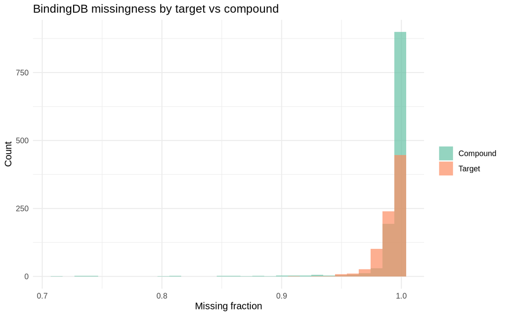

```r
bindingdb_missing <- tibble::tibble(
  missing_fraction = c(row_missing, col_missing),
  axis = rep(c("Target", "Compound"), c(length(row_missing), length(col_missing)))
)

ggplot(bindingdb_missing, aes(x = missing_fraction, fill = axis)) +
  geom_histogram(bins = 30, alpha = 0.7, position = "identity") +
  scale_fill_brewer(palette = "Set2") +
  labs(
    title = "BindingDB missingness by target vs compound",
    x = "Missing fraction",
    y = "Count",
    fill = ""
  ) +
  theme_minimal()
```

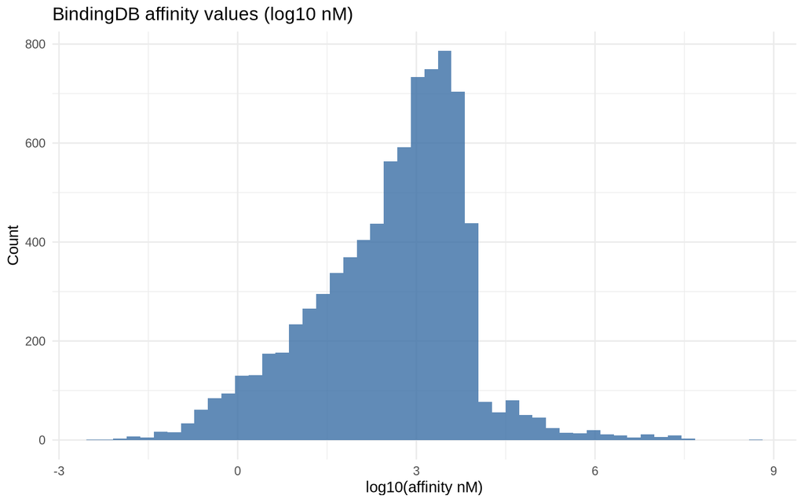

```r
bindingdb_vals <- as.numeric(assay_mat)
bindingdb_vals <- bindingdb_vals[!is.na(bindingdb_vals) & bindingdb_vals > 0]

ggplot(tibble::tibble(log10_affinity = log10(bindingdb_vals)), aes(x = log10_affinity)) +
  geom_histogram(bins = 50, fill = "#3A6EA5", alpha = 0.8) +
  labs(
    title = "BindingDB affinity values (log10 nM)",
    x = "log10(affinity nM)",
    y = "Count"
  ) +
  theme_minimal()
```

We note that the data from BindingDB is quite sparse. This is due to the curation process we used for version 1 which only analyzes the data from BindingDB that database had curated from literature. As such at present the overlap between those compounds and the content of AnnotationDB is small. As AnnotationDB is actively being expanded we anticipate this will change in the near future.

## 5.2 Bioassays

A compound-by-assay matrix of PubChem bioassay outcomes. Rows are AIDs (assay identifiers) and columns are PubChem CIDs. Entries are categorical (Active, Inactive, Not Measured).

```r
se <- experiments(hdd_v1)[["Bioassays"]]
assay_mat <- assay(se)

c(rows = nrow(assay_mat), cols = ncol(assay_mat))
```

```
## rows cols
##   21 3488
```

```r
assay_mat[1:min(5, nrow(assay_mat)), 1:min(6, ncol(assay_mat))]
```

|  | 51 | 187 | 190 | 199 | 243 | 244 |
| --- | --- | --- | --- | --- | --- | --- |
| AID_995 | Active | Not Measured | Active | Active | Active | Active |
| AID_1030 | Active | Active | Active | Active | Active | Active |
| AID_1631 | Not Measured | Not Measured | Not Measured | Not Measured | Not Measured | Not Measured |
| AID_1777 | Not Measured | Not Measured | Not Measured | Not Measured | Not Measured | Not Measured |
| AID_2101 | Active | Active | Active | Active | Active | Active |

```r
# Category counts
assay_mat_chr <- as.matrix(assay_mat)
assay_values <- as.character(assay_mat_chr)
category_counts <- sort(table(assay_values, useNA = "ifany"), decreasing = TRUE)
category_counts
```

```
## assay_values
## Not Measured       Active     Inactive
##        50679        21569         1000
```

```r
# Missingness proxy: Not Measured rate per assay
not_measured_rate <- rowMeans(assay_mat_chr == "Not Measured")
summary(not_measured_rate)
```

```
##    Min. 1st Qu.  Median    Mean 3rd Qu.    Max.
##   0.515   0.585   0.713   0.692   0.715   1.000
```

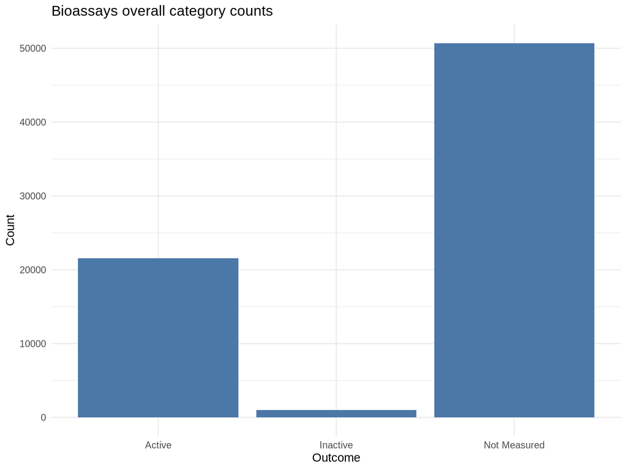

```r
bio_long <- as.data.frame(assay_mat_chr) %>%
  tibble::rownames_to_column("assay") %>%
  tidyr::pivot_longer(-assay, names_to = "compound", values_to = "status")
bio_long$status <- factor(bio_long$status, levels = c("Active", "Inactive", "Not Measured"))

ggplot(bio_long, aes(x = status)) +
  geom_bar(fill = "#4C78A8") +
  labs(
    title = "Bioassays overall category counts",
    x = "Outcome",
    y = "Count"
  ) +
  theme_minimal()
```

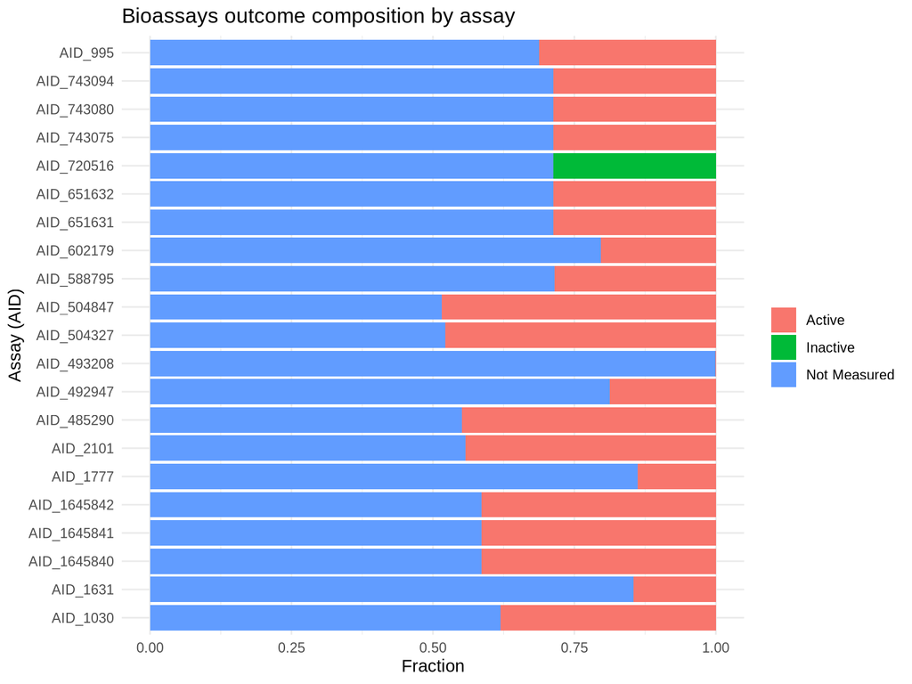

```r
ggplot(bio_long, aes(x = assay, fill = status)) +
  geom_bar(position = "fill") +
  coord_flip() +
  labs(
    title = "Bioassays outcome composition by assay",
    x = "Assay (AID)",
    y = "Fraction",
    fill = ""
  ) +
  theme_minimal()
```

## 5.3 Tox21

A compound-by-assay matrix for the Tox21 panel. Rows are Tox21 assays and columns are PubChem CIDs. Values are typically binary (0/1) with missing values for unmeasured compounds.

```r
se <- experiments(hdd_v1)[["Tox21"]]
assay_mat <- assay(se)

c(rows = nrow(assay_mat), cols = ncol(assay_mat))
```

```
## rows cols
##   12   31
```

```r
assay_mat[1:min(5, nrow(assay_mat)), 1:min(6, ncol(assay_mat))]
```

|  | 187 | 248 | 264 | 305 | 379 | 957 |
| --- | --- | --- | --- | --- | --- | --- |
| NR-AR | NA | 0 | 0 | 0 | 0 | 0 |
| NR-AR-LBD | NA | 0 | 0 | 0 | 0 | 0 |
| NR-AhR | NA | 0 | 0 | 0 | 0 | 0 |
| NR-Aromatase | NA | 0 | 0 | 0 | 0 | 0 |
| NR-ER | NA | 0 | 0 | 0 | 0 | 0 |

```r
# Value distribution
assay_mat_num <- as.matrix(assay_mat)
if ("mol_id" %in% rownames(assay_mat_num)) {
  assay_mat_num <- assay_mat_num[rownames(assay_mat_num) != "mol_id", , drop = FALSE]
}
table(as.vector(assay_mat_num), useNA = "ifany")
```

```
##
##    0    1 <NA>
##  297   23   52
```

```r
# Missingness per assay
summary(rowMeans(is.na(assay_mat_num)))
```

```
##    Min. 1st Qu.  Median    Mean 3rd Qu.    Max.
##  0.0000  0.0968  0.1452  0.1398  0.1935  0.2258
```

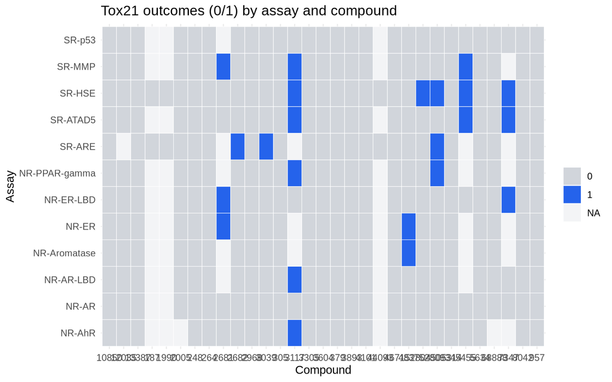

```r
tox21_long <- as.data.frame(assay_mat_num) %>%
  tibble::rownames_to_column("assay") %>%
  tidyr::pivot_longer(-assay, names_to = "compound", values_to = "value")
tox21_long$value_factor <- factor(tox21_long$value, levels = c(0, 1))

ggplot(tox21_long, aes(x = compound, y = assay, fill = value_factor)) +
  geom_tile(color = "white") +
  scale_fill_manual(values = c("0" = "#d1d5db", "1" = "#2563eb"), na.value = "#f3f4f6") +
  labs(
    title = "Tox21 outcomes (0/1) by assay and compound",
    x = "Compound",
    y = "Assay",
    fill = ""
  ) +
  theme_minimal()
```

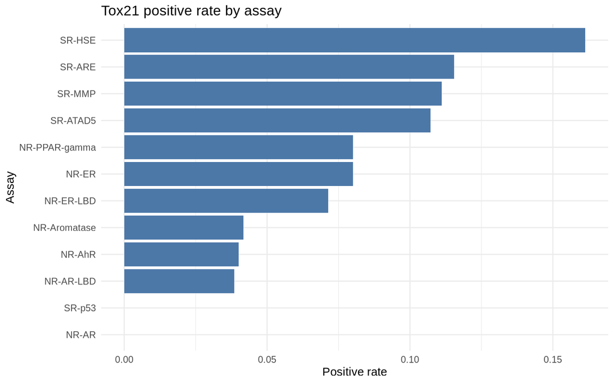

```r
tox21_rate <- tox21_long %>%
  group_by(assay) %>%
  summarize(positive_rate = mean(value == 1, na.rm = TRUE), .groups = "drop")

ggplot(tox21_rate, aes(x = reorder(assay, positive_rate), y = positive_rate)) +
  geom_col(fill = "#4C78A8") +
  coord_flip() +
  labs(
    title = "Tox21 positive rate by assay",
    x = "Assay",
    y = "Positive rate"
  ) +
  theme_minimal()
```

## 5.4 ToxCast

A compound-by-assay matrix for the ToxCast panel. Rows are assay endpoints and columns are PubChem CIDs. Values are typically binary (0/1) with missing values.

```r
se <- experiments(hdd_v1)[["ToxCast"]]
assay_mat <- assays(se)[[1]]

c(rows = nrow(assay_mat), cols = ncol(assay_mat))
```

```
## rows cols
##  617   25
```

```r
assay_mat[1:min(5, nrow(assay_mat)), 1:min(6, ncol(assay_mat))]
```

|  | 904 | 957 | 1990 | 2123 | 2682 | 3026 |
| --- | --- | --- | --- | --- | --- | --- |
| ACEA_T47D_80hr_Negative | NA | 0 | NA | NA | 0 | 1 |
| ACEA_T47D_80hr_Positive | NA | 0 | NA | NA | 0 | 0 |
| APR_HepG2_CellCycleArrest_24h_dn | NA | 0 | NA | NA | 0 | 0 |
| APR_HepG2_CellCycleArrest_24h_up | NA | 0 | NA | NA | 0 | 0 |
| APR_HepG2_CellCycleArrest_72h_dn | NA | 0 | NA | NA | 0 | 0 |

```r
# Value distribution
assay_mat_num <- as.matrix(assay_mat)
table(as.vector(assay_mat_num), useNA = "ifany")
```

```
##
##    0    1 <NA>
## 7323  703 7399
```

```r
# Missingness per assay
summary(rowMeans(is.na(assay_mat_num)))
```

```
##    Min. 1st Qu.  Median    Mean 3rd Qu.    Max.
##    0.00    0.28    0.40    0.48    0.88    1.00
```

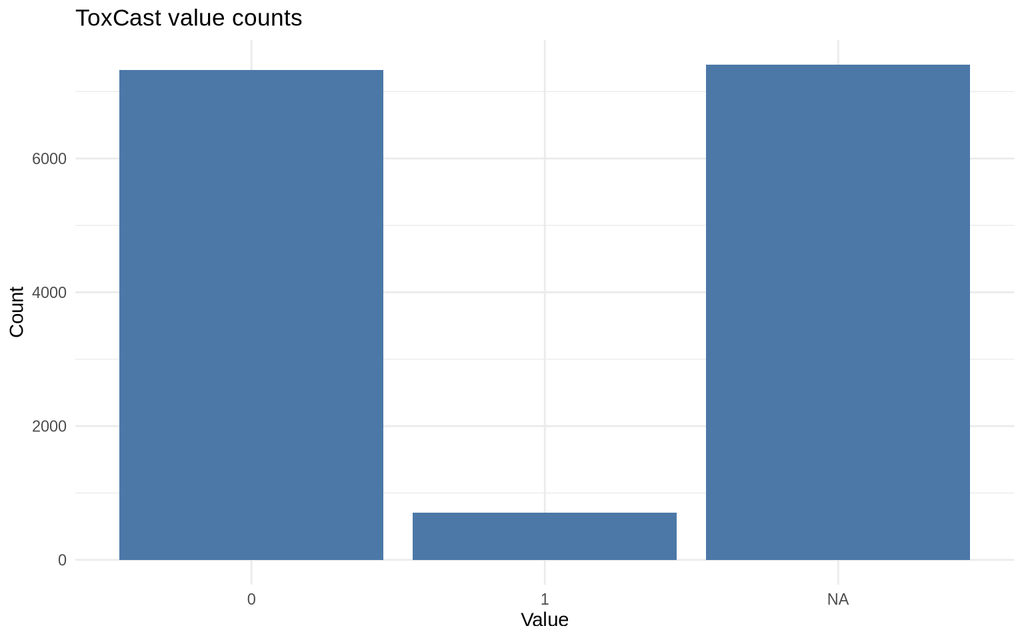

```r
toxcast_counts <- as.data.frame(table(value = as.vector(assay_mat_num), useNA = "ifany"))

ggplot(toxcast_counts, aes(x = value, y = Freq)) +
  geom_col(fill = "#4C78A8") +
  labs(
    title = "ToxCast value counts",
    x = "Value",
    y = "Count"
  ) +
  theme_minimal()
```

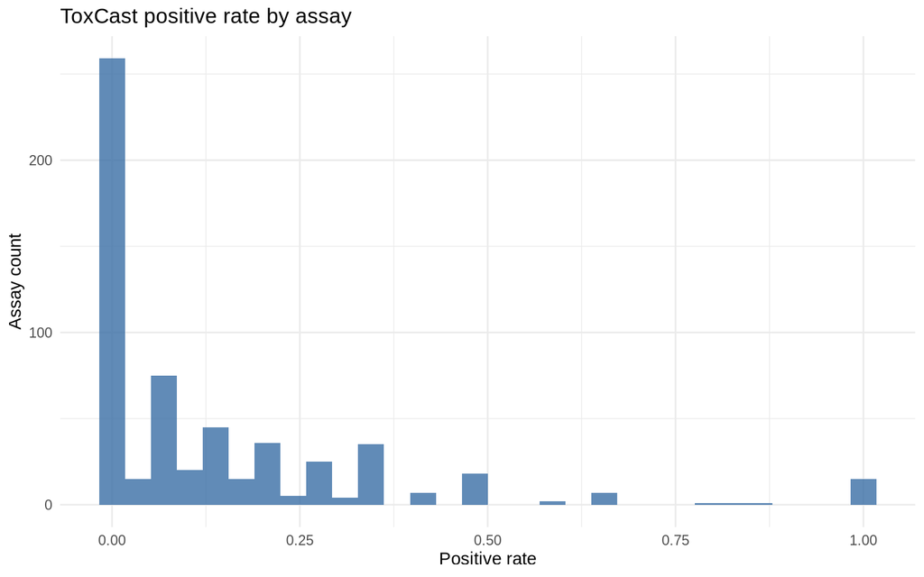

```r
row_non_missing <- rowSums(!is.na(assay_mat_num))
row_positive <- rowSums(assay_mat_num == 1, na.rm = TRUE)
row_rate <- row_positive / row_non_missing
row_rate <- row_rate[!is.na(row_rate)]

ggplot(tibble::tibble(positive_rate = row_rate), aes(x = positive_rate)) +
  geom_histogram(bins = 30, fill = "#3A6EA5", alpha = 0.8) +
  labs(
    title = "ToxCast positive rate by assay",
    x = "Positive rate",
    y = "Assay count"
  ) +
  theme_minimal()
```

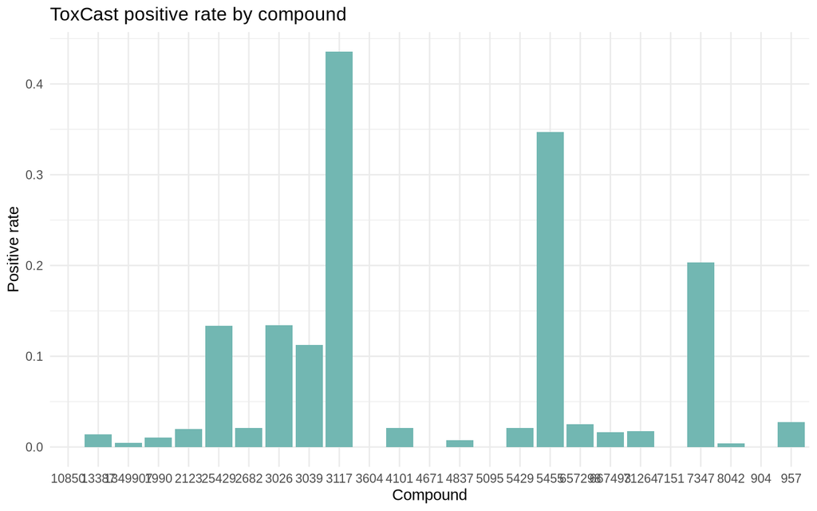

```r
col_non_missing <- colSums(!is.na(assay_mat_num))
col_positive <- colSums(assay_mat_num == 1, na.rm = TRUE)
col_rate <- col_positive / col_non_missing
toxcast_compound <- tibble::tibble(
  compound = colnames(assay_mat_num),
  positive_rate = as.numeric(col_rate)
)

ggplot(toxcast_compound, aes(x = compound, y = positive_rate)) +
  geom_col(fill = "#72B7B2") +
  labs(
    title = "ToxCast positive rate by compound",
    x = "Compound",
    y = "Positive rate"
  ) +
  theme_minimal()
```

## 5.5 ClinTox

A compound-by-label matrix for clinical toxicity outcomes. Rows correspond to the ClinTox labels (e.g., FDA approval and toxicity) and columns are PubChem CIDs. Values are binary (0/1) with missing values for compounds not present in the source dataset.

```r
se <- experiments(hdd_v1)[["ClinTox"]]
assay_mat <- assay(se)

c(rows = nrow(assay_mat), cols = ncol(assay_mat))
```

```
## rows cols
##    2  118
```

```r
assay_mat[1:min(5, nrow(assay_mat)), 1:min(6, ncol(assay_mat))]
```

|  | 187 | 1176 | 1990 | 2187 | 2244 | 2481 |
| --- | --- | --- | --- | --- | --- | --- |
| FDA_APPROVED | 1 | 1 | 1 | 0 | 0 | 1 |
| CT_TOX | 0 | 0 | 0 | 1 | 1 | 0 |

```r
# Value distribution
assay_mat_num <- as.matrix(assay_mat)
table(as.vector(assay_mat_num), useNA = "ifany")
```

```
##
##   0   1
## 104 132
```

```r
# Missingness per label
summary(rowMeans(is.na(assay_mat_num)))
```

```
##    Min. 1st Qu.  Median    Mean 3rd Qu.    Max.
##       0       0       0       0       0       0
```

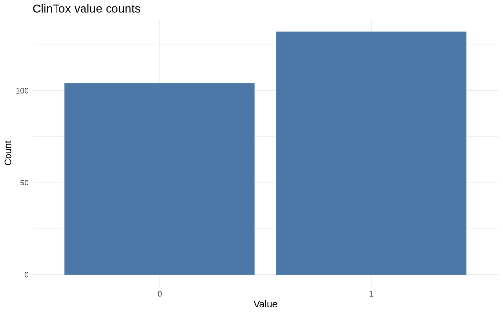

```r
clintox_counts <- as.data.frame(table(value = as.vector(assay_mat_num), useNA = "ifany"))

ggplot(clintox_counts, aes(x = value, y = Freq)) +
  geom_col(fill = "#4C78A8") +
  labs(
    title = "ClinTox value counts",
    x = "Value",
    y = "Count"
  ) +
  theme_minimal()
```

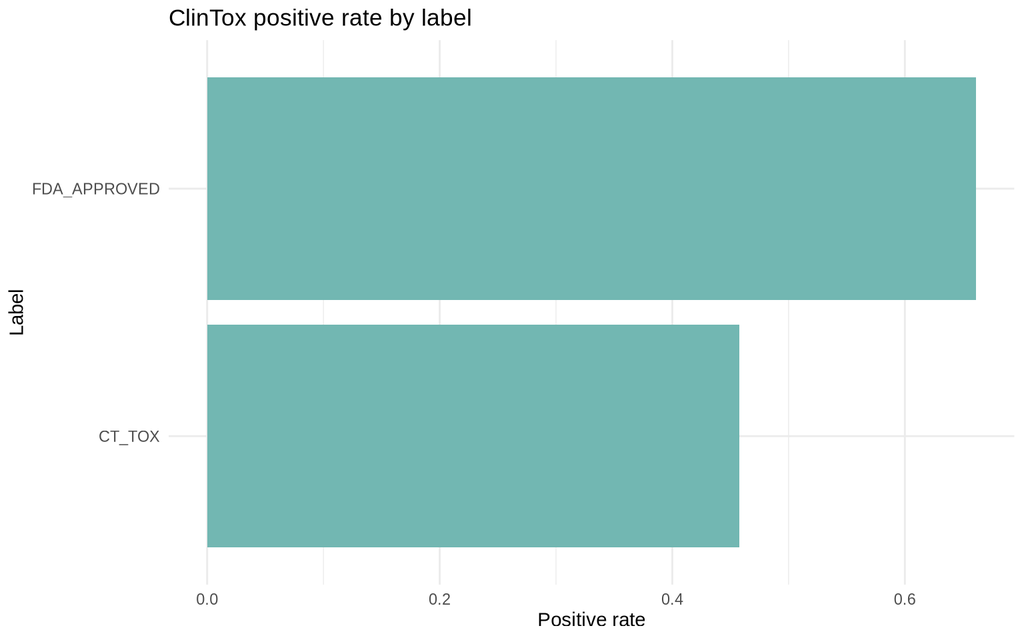

```r
row_non_missing <- rowSums(!is.na(assay_mat_num))
row_positive <- rowSums(assay_mat_num == 1, na.rm = TRUE)
row_rate <- row_positive / row_non_missing

clintox_label <- tibble::tibble(
  label = rownames(assay_mat_num),
  positive_rate = as.numeric(row_rate)
)

ggplot(clintox_label, aes(x = reorder(label, positive_rate), y = positive_rate)) +
  geom_col(fill = "#72B7B2") +
  coord_flip() +
  labs(
    title = "ClinTox positive rate by label",
    x = "Label",
    y = "Positive rate"
  ) +
  theme_minimal()
```

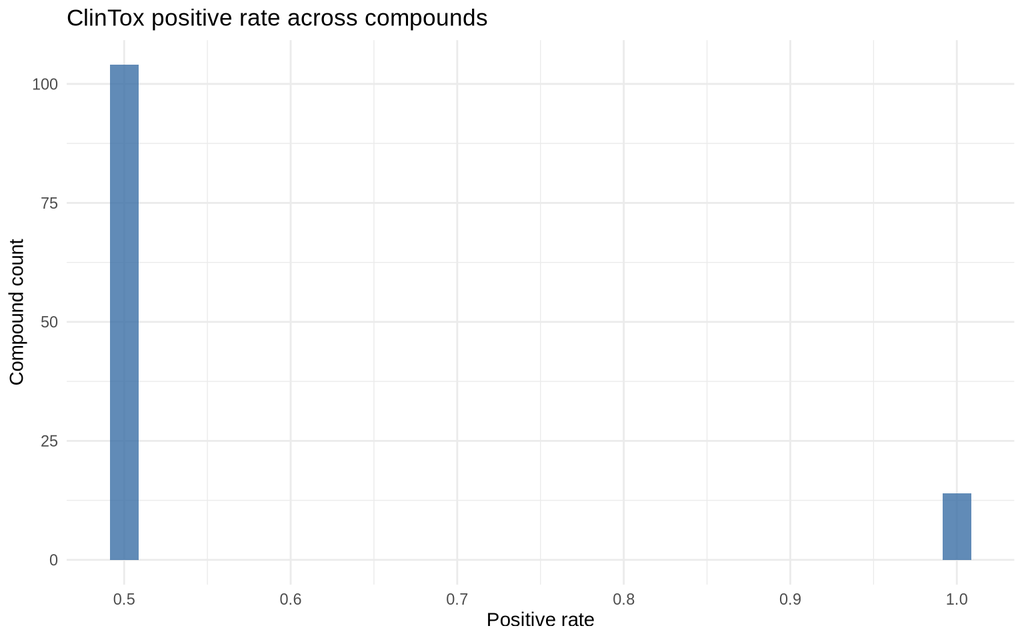

```r
col_non_missing <- colSums(!is.na(assay_mat_num))
col_positive <- colSums(assay_mat_num == 1, na.rm = TRUE)
col_rate <- col_positive / col_non_missing

ggplot(tibble::tibble(positive_rate = col_rate), aes(x = positive_rate)) +
  geom_histogram(bins = 30, fill = "#3A6EA5", alpha = 0.8) +
  labs(
    title = "ClinTox positive rate across compounds",
    x = "Positive rate",
    y = "Compound count"
  ) +
  theme_minimal()
```

## 5.6 SIDER

A compound-by-side-effect matrix derived from SIDER. Rows are side effect categories and columns are PubChem CIDs. Values are binary (0/1) with missing values when a compound is not represented.

```r
se <- experiments(hdd_v1)[["SIDER"]]
assay_mat <- assay(se)

c(rows = nrow(assay_mat), cols = ncol(assay_mat))
```

```
## rows cols
##   27  324
```

```r
assay_mat[1:min(5, nrow(assay_mat)), 1:min(6, ncol(assay_mat))]
```

```
##                                    187 244 305 338 564 598
## Hepatobiliary disorders              0   0   0   1   0   1
## Metabolism and nutrition disorders   0   0   0   1   0   1
## Product issues                       0   0   0   0   0   0
## Eye disorders                        1   1   0   0   1   1
## Investigations                       0   0   0   1   1   1
```

```r
# Value distribution
assay_mat_num <- as.matrix(assay_mat)
table(as.vector(assay_mat_num), useNA = "ifany")
```

```
##
##    0    1
## 3737 5011
```

```r
# Missingness per side effect
summary(rowMeans(is.na(assay_mat_num)))
```

```
##    Min. 1st Qu.  Median    Mean 3rd Qu.    Max.
##       0       0       0       0       0       0
```

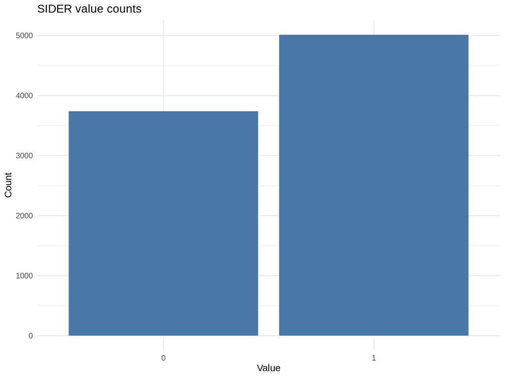

```r
sider_counts <- as.data.frame(table(value = as.vector(assay_mat_num), useNA = "ifany"))

ggplot(sider_counts, aes(x = value, y = Freq)) +
  geom_col(fill = "#4C78A8") +
  labs(
    title = "SIDER value counts",
    x = "Value",
    y = "Count"
  ) +
  theme_minimal()
```

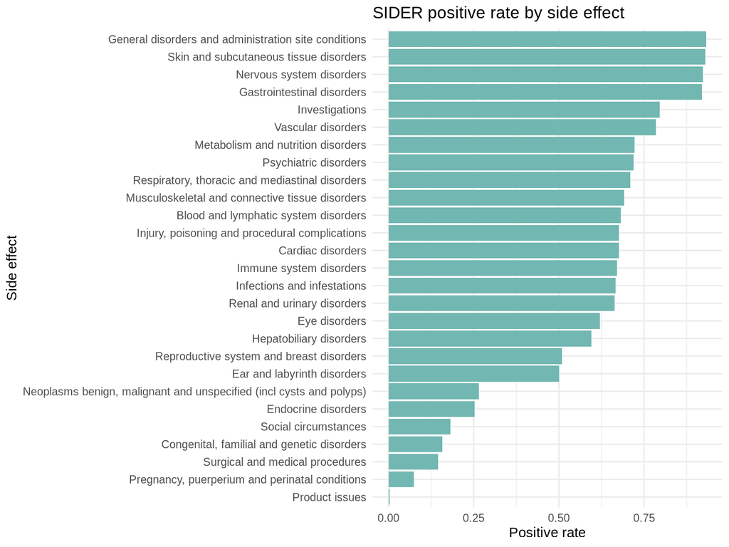

```r
row_non_missing <- rowSums(!is.na(assay_mat_num))
row_positive <- rowSums(assay_mat_num == 1, na.rm = TRUE)
row_rate <- row_positive / row_non_missing

sider_effects <- tibble::tibble(
  side_effect = rownames(assay_mat_num),
  positive_rate = as.numeric(row_rate)
)

ggplot(sider_effects, aes(x = reorder(side_effect, positive_rate), y = positive_rate)) +
  geom_col(fill = "#72B7B2") +
  coord_flip() +
  labs(
    title = "SIDER positive rate by side effect",
    x = "Side effect",
    y = "Positive rate"
  ) +
  theme_minimal()
```

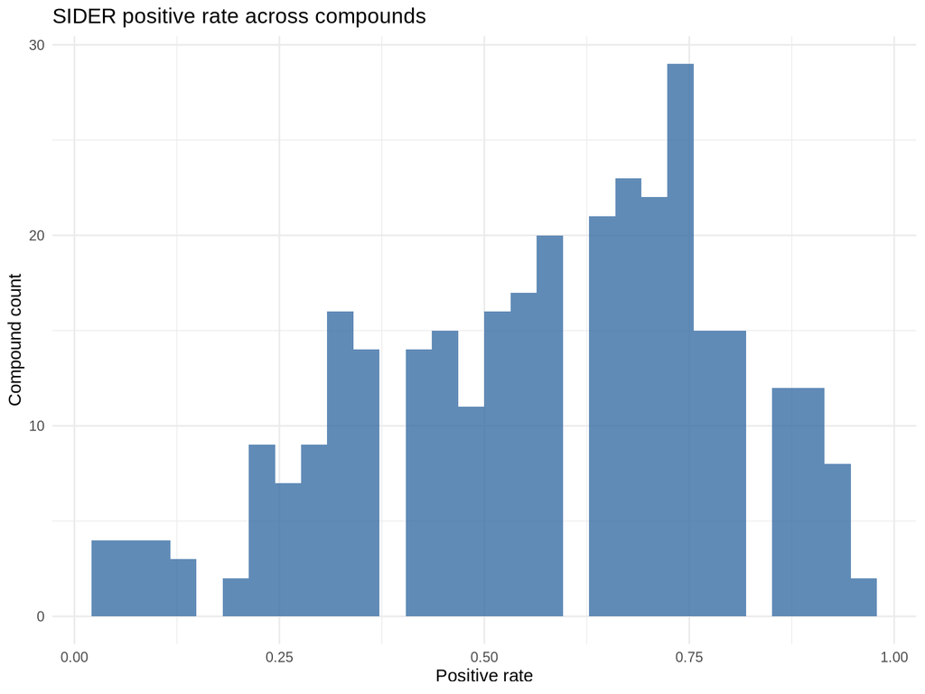

```r
col_non_missing <- colSums(!is.na(assay_mat_num))
col_positive <- colSums(assay_mat_num == 1, na.rm = TRUE)
col_rate <- col_positive / col_non_missing

ggplot(tibble::tibble(positive_rate = col_rate), aes(x = positive_rate)) +
  geom_histogram(bins = 30, fill = "#3A6EA5", alpha = 0.8) +
  labs(
    title = "SIDER positive rate across compounds",
    x = "Positive rate",
    y = "Compound count"
  ) +
  theme_minimal()
```

## 5.7 Fingerprints (Morgan count fingerprints)

Count-based Morgan fingerprints generated from SMILES for each compound using RDKit. Each fingerprint experiment is stored as a sparse matrix of feature counts with rows as fingerprint bins and columns as PubChem CIDs.

```r
fp_names <- grep("^fingerprint\\.", experiment_names, value = TRUE)
fp_names
```

```
## [1] "fingerprint.Morgan.2.1024" "fingerprint.Morgan.2.2048"
## [3] "fingerprint.Morgan.2.512"  "fingerprint.Morgan.3.1024"
## [5] "fingerprint.Morgan.3.2048" "fingerprint.Morgan.3.512"
```

```r
for (fp_name in fp_names) {
  se <- experiments(hdd_v1)[[fp_name]]
  assay_mat <- assays(se)[[1]]

  cat("\nFingerprint:", fp_name, "\n")
  cat("Dimensions:", nrow(assay_mat), "x", ncol(assay_mat), "\n")

  # Sparsity for sparse matrices
  if (inherits(assay_mat, "sparseMatrix")) {
    sparsity <- 1 - Matrix::nnzero(assay_mat) / length(assay_mat)
    cat("Sparsity:", round(sparsity, 4), "\n")
  }

  print(assay_mat[1:min(5, nrow(assay_mat)), 1:min(6, ncol(assay_mat))])
}
```

```
##
## Fingerprint: fingerprint.Morgan.2.1024
## Dimensions: 1024 x 3488
## Sparsity: 0.958
## 5 x 6 sparse Matrix of class "dgCMatrix"
##      51 187 190 199 243 244
## [1,]  .   .   .   .   .   .
## [2,]  .   .   .   .   .   .
## [3,]  .   .   .   .   .   .
## [4,]  .   .   .   .   .   .
## [5,]  .   .   .   .   .   .
##
## Fingerprint: fingerprint.Morgan.2.2048
## Dimensions: 2048 x 3488
## Sparsity: 0.979
## 5 x 6 sparse Matrix of class "dgCMatrix"
##      51 187 190 199 243 244
## [1,]  .   .   .   .   .   .
## [2,]  .   .   .   .   .   .
## [3,]  .   .   .   .   .   .
## [4,]  .   .   .   .   .   .
## [5,]  .   .   .   .   .   .
##
## Fingerprint: fingerprint.Morgan.2.512
## Dimensions: 512 x 329
## Sparsity: 0.918
## 5 x 6 sparse Matrix of class "dgCMatrix"
##      896 938 1046 1727 1775 1935
## [1,]   1   .    .    .    .    .
## [2,]   .   .    .    .    .    .
## [3,]   .   .    .    .    .    .
## [4,]   .   .    .    .    .    .
## [5,]   .   .    .    .    .    2
##
## Fingerprint: fingerprint.Morgan.3.1024
## Dimensions: 1024 x 3488
## Sparsity: 0.943
## 5 x 6 sparse Matrix of class "dgCMatrix"
##      51 187 190 199 243 244
## [1,]  .   .   .   .   .   .
```

[output cut: 11 more lines]

```
## [2,]  .   .   .   .   .   .
## [3,]  .   .   .   .   .   .
## [4,]  .   .   .   .   .   .
## [5,]  .   .   .   .   .   .
##
## Fingerprint: fingerprint.Morgan.3.512
## Dimensions: 512 x 329
## Sparsity: 0.891
## 5 x 6 sparse Matrix of class "dgCMatrix"
##      896 938 1046 1727 1775 1935
## [1,]   1   .    .    .    .    .
## [2,]   1   .    .    .    .    .
## [3,]   .   .    .    .    .    .
## [4,]   .   .    .    .    .    .
## [5,]   .   .    .    .    .    2
```

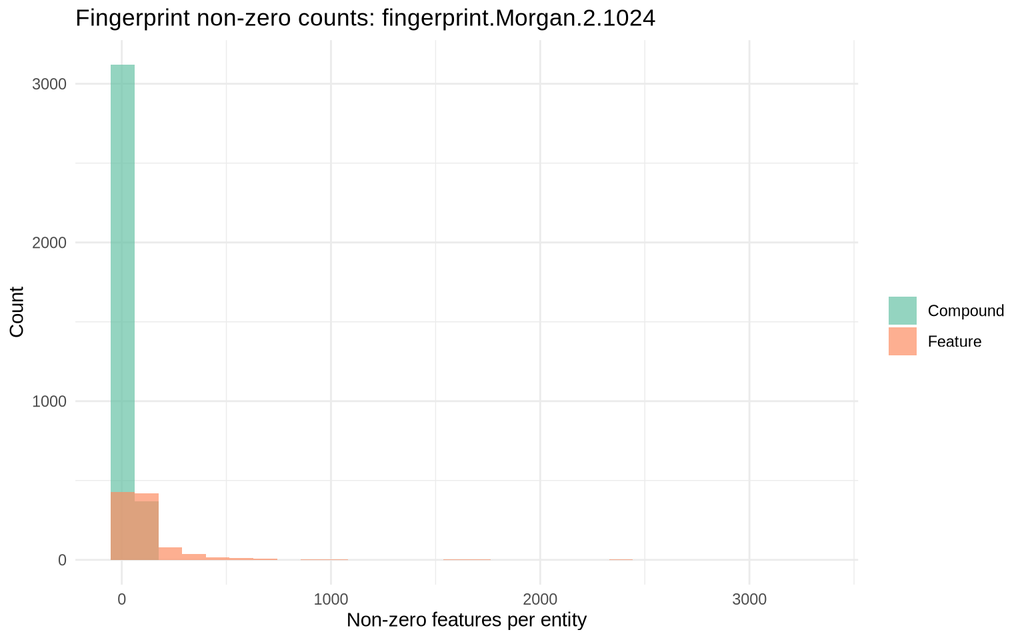

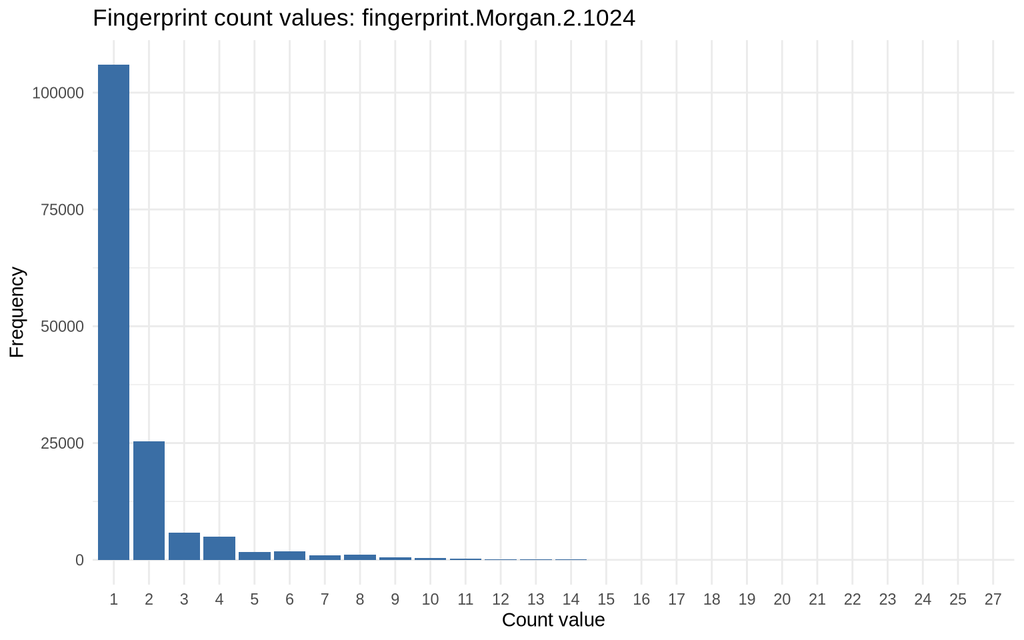

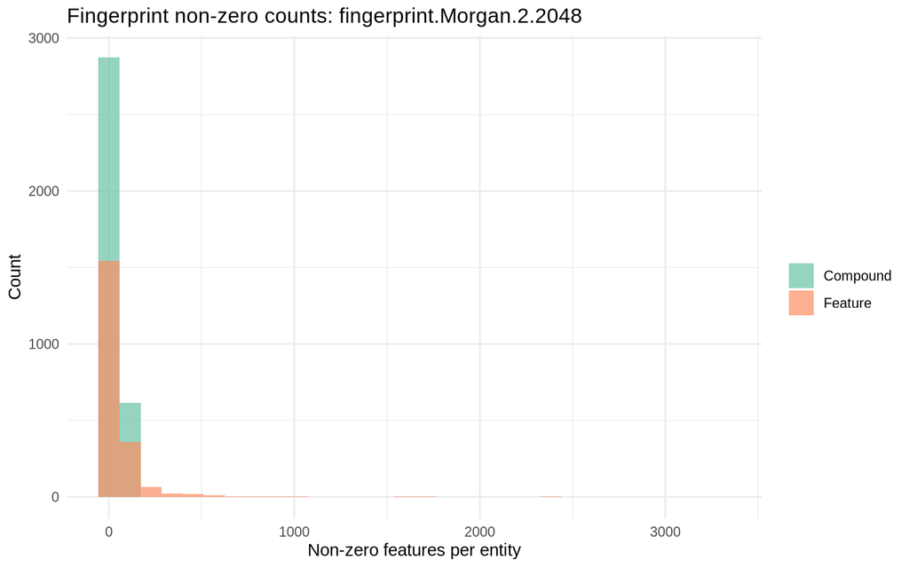

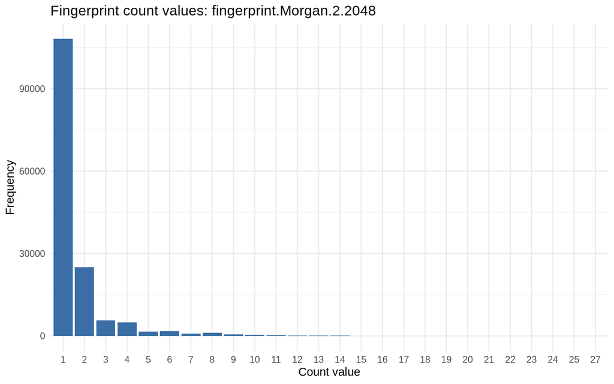

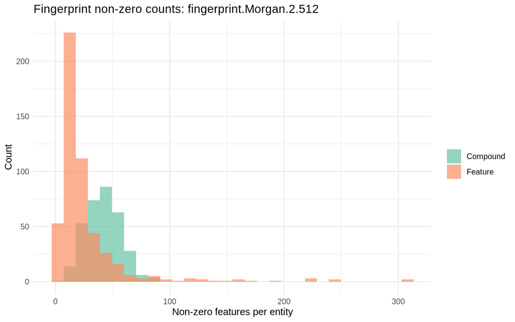

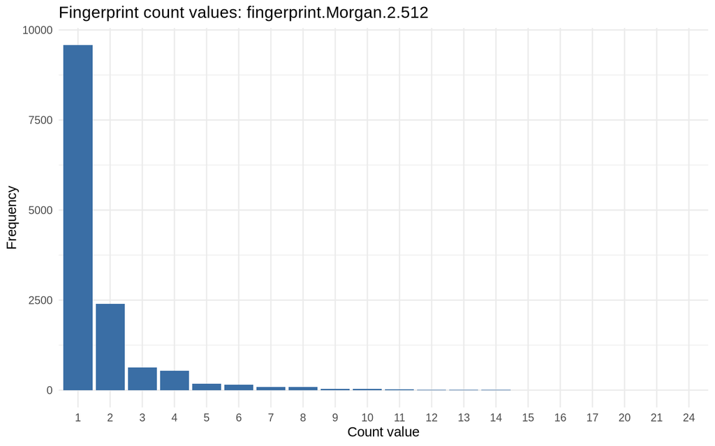

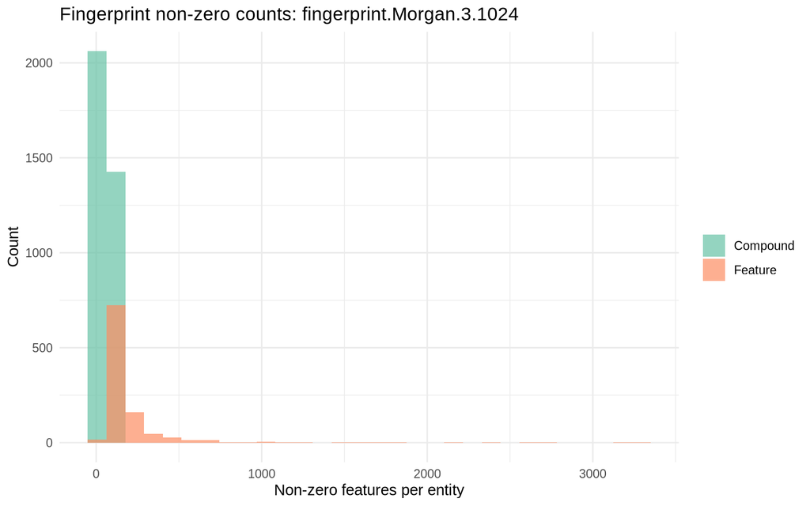

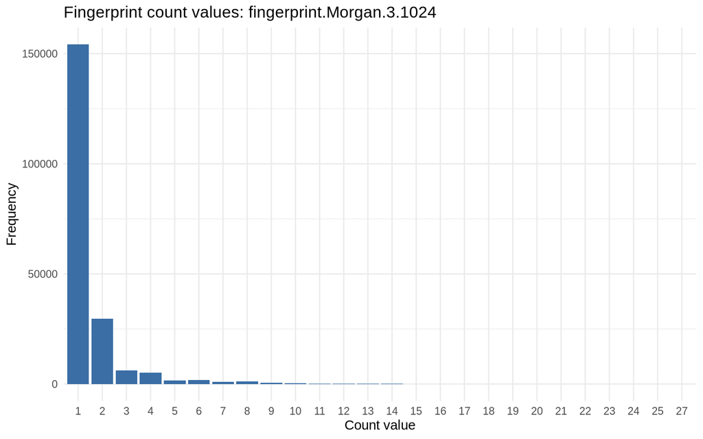

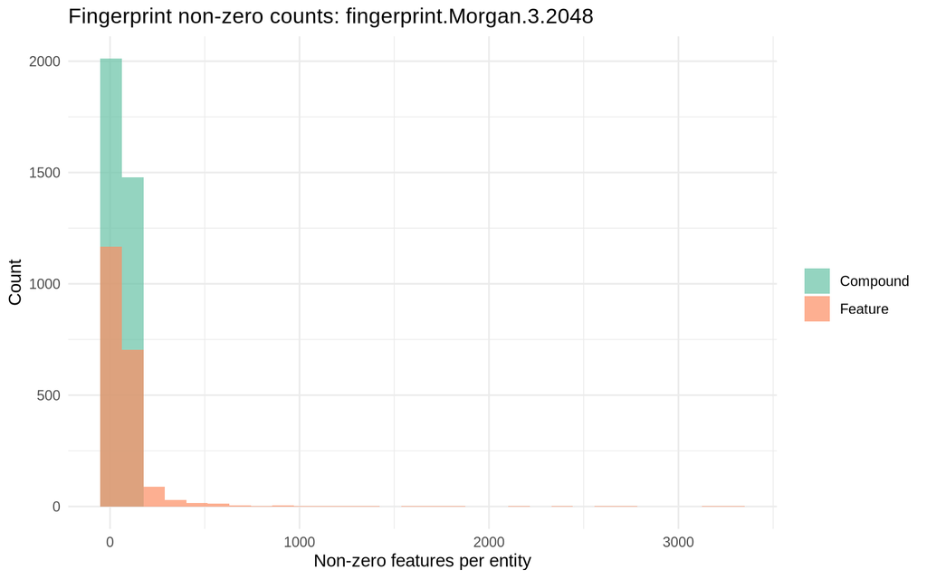

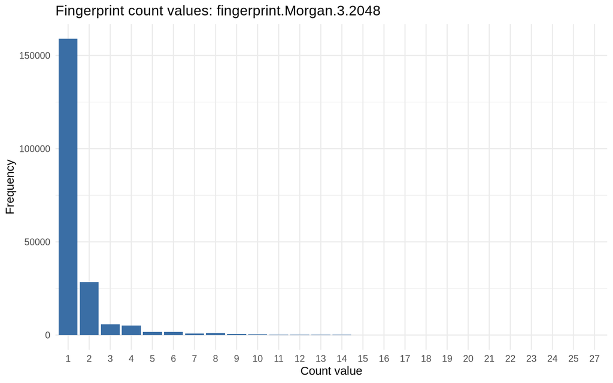

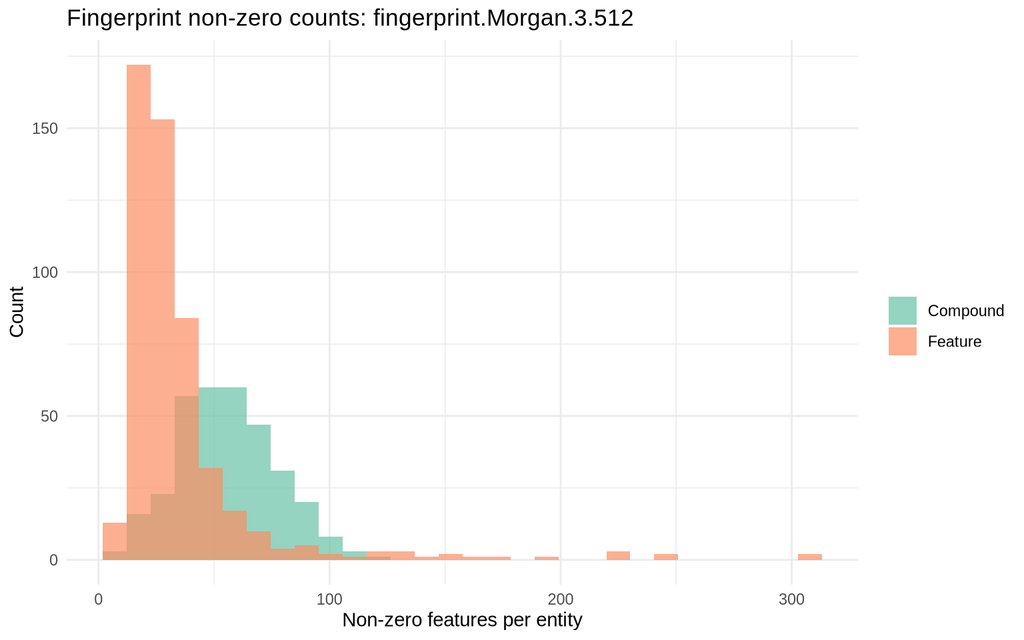

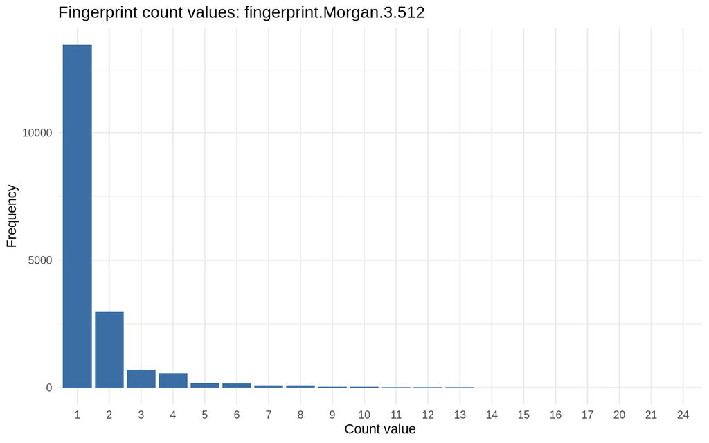

```r
for (fp_name in fp_names) {
  se <- experiments(hdd_v1)[[fp_name]]
  assay_mat <- assays(se)[[1]]

  col_nnz <- Matrix::colSums(assay_mat > 0)
  row_nnz <- Matrix::rowSums(assay_mat > 0)

  nnz_df <- tibble::tibble(
    count = c(as.numeric(col_nnz), as.numeric(row_nnz)),
    axis = rep(c("Compound", "Feature"), c(length(col_nnz), length(row_nnz)))
  )

  p_nnz <- ggplot(nnz_df, aes(x = count, fill = axis)) +
    geom_histogram(bins = 30, alpha = 0.7, position = "identity") +
    scale_fill_brewer(palette = "Set2") +
    labs(
      title = paste("Fingerprint non-zero counts:", fp_name),
      x = "Non-zero features per entity",
      y = "Count",
      fill = ""
    ) +
    theme_minimal()

  nonzero_vals <- assay_mat@x
  val_df <- as.data.frame(table(value = nonzero_vals))

  p_vals <- ggplot(val_df, aes(x = value, y = Freq)) +
    geom_col(fill = "#3A6EA5") +
    labs(
      title = paste("Fingerprint count values:", fp_name),
      x = "Count value",
      y = "Frequency"
    ) +
    theme_minimal()

  print(p_nnz)
  print(p_vals)
}
```

## 5.8 Computing with Morgan Fingerprints

```r
col.Data <- colData(hdd_v1) %>% as.data.frame()
table(col.Data$DILI.Severity)
```

```
##
##    0    2    3    4    5    6    7    8
## 3178   27  134   20   30    3   23   73
```

We will frame predicting DILI severity as a binary classification problem. To this we will subset the data into high DILI scores (scores of 7 or 8) and low DILI (scores of 2 or 3).

```r
high.scores <- c(7,8)
low.scores <- c(2,3)

dili.High <- col.Data %>% filter(DILI.Severity %in% high.scores) %>% select(Pubchem.CID)
dili.Low <- col.Data %>% filter(DILI.Severity %in% low.scores) %>% select(Pubchem.CID)
```

Now lets make training and testing datasts using the Morgan fingerprint with radius 3 and with 512 bits. The training set will be 80% of the data we have.

```r
set.seed(1234)

fps <- assays(hdd_v1)[["fingerprint.Morgan.3.512"]]

fp.cids <- colnames(fps)
high.cids <- intersect(as.character(dili.High$Pubchem.CID), fp.cids)
low.cids <- intersect(as.character(dili.Low$Pubchem.CID), fp.cids)

high.fps <- as.matrix(t(fps[, high.cids, drop = FALSE]))
low.fps <- as.matrix(t(fps[, low.cids, drop = FALSE]))

X <- rbind(high.fps, low.fps)
rownames(X)<-NULL
y <- c( rep(1,dim(high.fps)[1]), rep(0,dim(low.fps)[1]))

split.idx <- sample(c(TRUE, FALSE), dim(X)[1], replace=TRUE, prob=c(0.8, 0.2))

X.train <- X[split.idx,]
y.train <- y[split.idx]

X.test <- X[!split.idx,]
y.test <- y[!split.idx]
```

Lastly we fit a logistic regression model and evaluate our prediction in terms of classification accuracy:

```r
model <- cv.glmnet(X.train, y.train, family = 'binomial')
preds <- as.numeric(predict(model,X.test,type='class'))

accuracy <- sum(y.test ==preds)/length(y.test)
accuracy
```

```
## [1] 0.677
```